# PyLayers

## An Indoor Propagation Tool for Studying Localization in WBAN Context

## IC1004 COST Meeting Aalborg 2014

## Nicolas Amiot, Meriem Mhedhbi,Stéphane Avrillon

## Bernard Uguen

### Presentation available @ http://tinyurl.com/nlprrkj

# Outline

- What is PyLayers ?
- Indoor Radio Propagation Modeling
- Handling mobility for WBAN
  - Large scale
  - Body scale
- Perspectives

# What is PyLayers ?

- An **Open Source** platform for **education and research**
- Writen in **Python**
- **Evolutive**
  - git versioned
  - documented from the source code
  - tested (not enough probably...)
- **Modular**
  - specialized modules
  - [gis,antprop,simul,signal,mobility,util,...]
- **Interactive**
  - IPython notebook
- **Object Oriented**
  - help(), show() and `__repr__`
- **Data Oriented**
  - Using Hierarchical data storage (*HDF5*)

# Features and Applications

- Production of radio observables for **localization in Indoor environments**
- Analysis of channel measurements
- Fast Indoor coverage using Motley Keenan model
- Various radio standards including **UWB** radio (to be extended)
- Combining propagation modeling and **human mobility** (Indoor pedestrian D2D)

# Indoor Layout Description

```python
L=Layout('WHERE2.ini')
```

[figure not shown]

### Office building with Graph of rooms

[figure not shown]

### Indoor Layout with precalculated visibility graph

```python
rx = RadioNode(_fileini='w2m1rx.ini',_fileant='defant.vsh3')
tx = RadioNode(_fileini='w2m1tx.ini',_fileant='defant.vsh3')
```

[figure not shown]

### W1 M1 Dataset. IR-UWB CEA Leti Testbed - 4 Rx (in Red)- 275 Tx (in Blue)- [WHERE1D4.1]

# Link Simulation

- Links are saved in `hdf5` format
- All Links data members are evaluated once and stored
- `In [1]: Lk = DLink(L=L,a=tx.points[2],b=rx.points[24],cutoff=3)`
- `In [2]: Lk.eval()`

[figure not shown]

### Defining a Radio Link between 2 cycles

## The Ray **Signature** `.Si`

Signature is somehow related to the concept of **common clusters** or **ray persistency**

```python
Lk.Si.keys()
k = 4
print "Number of Signatures : ",Lk.Si[4].shape[0]/2
print "signature (interaction entities index) :",Lk.Si[k][0,:]
print "signature (interaction type) :",Lk.Si[k][1,:]
```

```
Number of Signatures :  872
signature (interaction entities index) : [ 22  30 135  38]
signature (interaction type) : [2 3 3 2]
```

- Signatures are rays potentialities
- A set of Signatures is calculated from one Layout cycle to an other Layout cycle
- A Signature consists of 2 lists
  - A list of interaction entities (point (<0) or segment (>0))
  - A list of type of interaction (1:D, 2:R, 3:T)
- A **same signature** is used for calculation of rays from one cycle to an other cycle

# 3D Rays (ceil and floor miroring)

```python
Lk.R
```

```
Rays3D
----------
2 / 1 : [0]
3 / 4 : [1 2 3 4]
4 / 13 : [ 5  6  7  8  9 10 11 12 13 14 15 16 17]
5 / 20 : [18 19 20 21 22 23 24 25 26 27 28 29 30 31 32 33 34 35 36 37]
6 / 18 : [38 39 40 41 42 43 44 45 46 47 48 49 50 51 52 53 54 55]
7 / 4 : [56 57 58 59]
-----
ni : 302
nl : 664
```

- Rays are grouped by blocks of same number of interactions
- Each block of rays is evaluated as a whole for all interactions (R,T) as a whole

[figure not shown]

```python
c = plt.cm.jet
col = c(1.0)
f,a = Lk.R.show(L=Lk.L,figsize=(20,5),i=3,r=0,alpharay=0.3,widthray=5,colray=col)
savefig('./files/W1LOS.png')
```

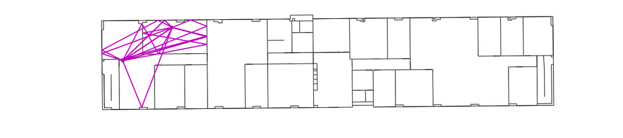

```python
f,a = Lk.R.show(L=Lk.L,figsize=(20,5),i=4,widthray=2,colray='m')
```

[figure not shown]

### Dynamic 50dB

[figure not shown]

### Dynamic 120dB

# The Propagation Channel `.C` : class `Ctilde`

- Full polarization
- UWB
- Full angular information

$\mathbf{\tilde{C}(f)} = \left[\matrix { C_{\theta,\theta} & C_{\theta,\phi}\\C_{\phi,\theta} & C_{\phi,\phi}}\right]$

# The Propagation Channel `.C`

```python
Lk.C
```

```
Ctilde
---------
(60, 181)
Nray : 60
fmin(GHz) : 2.0
fmax(GHz): 11.0
Nfreq : 181
```

[figure not shown]

### 60 rays, 181 frequency points

# The Propagation Channel `.C` (Angular Information)

[figure not shown]

# Antennas `.Aa` `.Ab`

```python
Lk.Aa=Antenna('defant.vsh3',source='cst')
Lk.Ab=Antenna('defant.vsh3',source='cst')
```

- Antenna are compressed either in
  - **Scalar Spherical Harmonics** (.sh3)
  - **Vector spherical harmonics** (.vsh3)

```python
Lk.Aa
```

[output not shown]

[figure not shown]

### Evolution of Spherical Harmonics Coeff w.r.t cylinder phantom (radius=10cm) distance [Mhed14]

# The transmission channel `.H` (class `Tchannel`)

```python
r=Lk.H.applywavB(wav.sfg)
```

[output not shown]

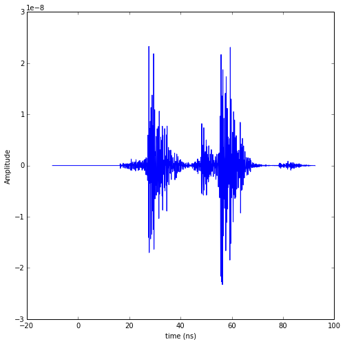

```python
r.plot(typ='v')
```

# Handling human mobility

- Human mobility is handled with a Discrete Event Simulator based on SimPy

```python
YouTubeVideo('vNwzZVoE4mI')
```

[video not shown]

[figure not shown]

### Positions of the body equipped with radio devices along a synthetic trajectory

# Conclusion - On Going Work

# References

**[Mhed14]** Meriem Mhedhbi, Stéphane Avrillon, Troels Pedersen, and Bernard Uguen. [*Modelling of UWB antenna perturbed by human phantom in spherical harmonics space*](http://vbn.aau.dk/files/195257751/1569855541.pdf). In The 8th European Conference on Antennas and Propagation (EuCAP 2014) (EuCAP 2014), The Hague, The Netherlands, April 2014

**[MotionCapture]** [Cmu graphics lab motion capture database : Subject 7: walk (0701.c3d).](http://mocap.cs.%20cmu.edu/search.php?subjectnumber=%&motion=%)

```python
HTML('<iframe src=http://www.pylayers.org width=1000 height=350></iframe>')
```

[interactive chart not shown]